# Diatom-based paleoenviromental reconstruction from Northern Patagonia

Camilo Vélez

15/8/2021

Seven sedimentary cores were analyzed. Diatom zones characterized by cluster analysis in the fossil sequences were correlated and the diatom content was compared with modern assemblages using specific multivariate ordination analysis (NMDS).

```r
species.complet <- readRDS("species.complet.rds")
```

# **Bubble Plot For Fossil Assemblages**

A bubble plot was performed to compare the distribution of the most abundant fossil taxa in the samples. The bubbles are filled with different colors and each one represents the relative abundance (according to its size) of the species in the samples.

```r
species.red <- readRDS("species.red.rds")

species.red <- gather(
  species.red,
  "Species",
  "Abundance", -c(1,2)
  )
```

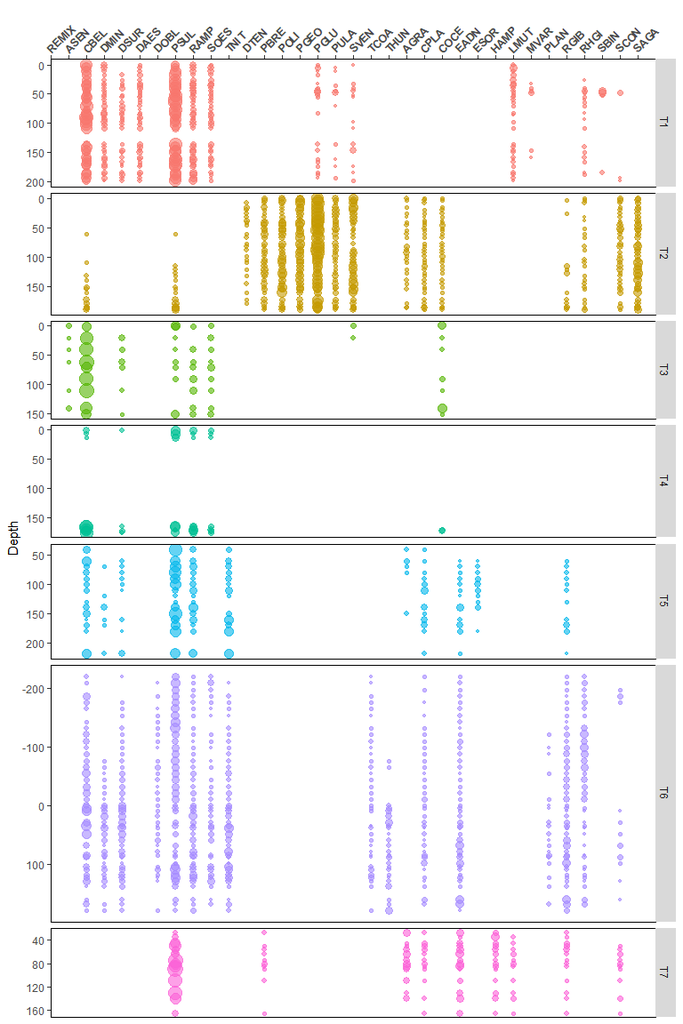

```r
ggplot(
  aes(x = Species, y = Depth, size = ifelse(Abundance==0, NA, Abundance), colour = Core),
  data = species.red
  ) +
  geom_point(
    alpha = 0.6,
    show.legend = F
    ) +
  scale_x_discrete(
    limits = species.red$Species,
    position = "top"
    ) +
  scale_y_continuous(
    trans = "reverse"
    ) +
  labs(
    x = "",
    y = "Depth"
    ) +
  facet_grid(
    rows = vars(Core),
    scales = "free_y",
    space = "free_y"
    ) +
  theme(
    panel.background = element_blank(),
    panel.grid.major = element_blank(),
    panel.border = element_rect(color = "black", fill = NA),
    axis.text.x = element_text(face = "bold", angle = 45, hjust = 0)
    )
```